# assignment04

Author

Katie Ward and Ben Burnley

## Set-Up

Our data are from [Pew Research Center’s American Trends Panel Wave 101](https://www.pewresearch.org/american-trends-panel-datasets/). This survey asks a battery of traditional political questions and this particular wave focused on political priorities. The survey was in the field January 10 – January 17, 2022.

## Chart 1

**Show data cleaning code**

```r
# create data for first chart
chart1data <- data %>%
  filter(F_PARTYSUM_FINAL == 1 | F_PARTYSUM_FINAL == 2 ) %>%
  mutate(parties = case_when(F_PARTYSUM_FINAL == 1 ~"Republican/Lean Repub.",
                             F_PARTYSUM_FINAL == 2 ~ "Democrat/Lean Dem.",
                             TRUE~NA_character_)) %>%
  mutate(religiousactivity = case_when(F_ATTEND ==1 ~ "More than once a week",
                                       F_ATTEND == 2 ~ "Once a week",
                                       F_ATTEND == 3 ~ "Once or twice a month",
                                       F_ATTEND ==4 ~ "A few times a year",
                                       F_ATTEND ==5 ~ "Seldom",
                                       F_ATTEND ==6 ~ "Never",
                                       TRUE~NA_character_ ))

# create levels for religious activity variable
rel_levels = c("Never", "Seldom", "A few times a year", "Once or twice a month", "Once a week", "More than once a week")

# factor the religious activity variable
chart1data <- chart1data %>%
  mutate(religiousactivity = factor(religiousactivity, levels = rel_levels))
```

**Show code for chart**

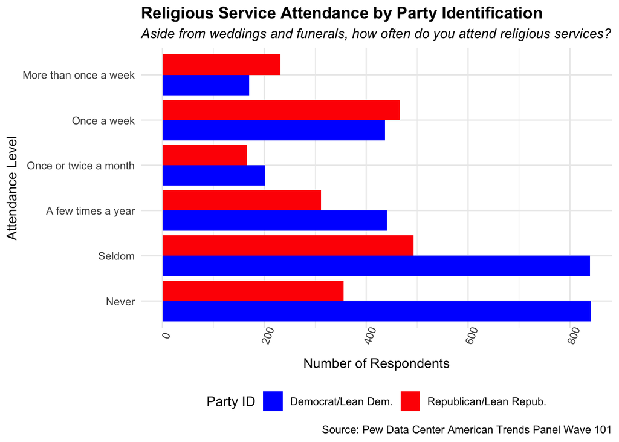

```r
chart1 <- chart1data %>%
  filter(!is.na(religiousactivity)) %>%
  ggplot(aes(religiousactivity, fill=parties)) +
  geom_bar(position = "dodge") +
  scale_fill_manual(values = c("blue", "red")) +
  coord_flip() +
  theme_minimal() +
  labs(
    title = "Religious Service Attendance by Party Identification",
    subtitle = "Aside from weddings and funerals, how often do you attend religious services?",
    x = "Attendance Level",
    y = "Number of Respondents",
    caption = "Source: Pew Data Center American Trends Panel Wave 101",
    fill = "Party ID"
  ) +
  theme(
    axis.text.x = element_text(angle = 70),
    legend.position = "bottom",
    plot.title = element_text(face = "bold"),
    plot.subtitle = element_text(face = "italic")
  )

chart1
```

The graph above shows the relationship between party identification and religious service attendance. A large number of the respondents who identify as Democrats report attending religious services “never” or “seldom”. For respondents that identify as Republican, there is a greater number that attend more frequently. The difference between the parties is not as large as expected in those who attend religious services once a week to once a month.

## Chart 2

**Show data cleaning code**

```r
chart2data <- chart1data %>%
  filter(SATIS_W101 != 99) %>%
  mutate(satisfied = ifelse(SATIS_W101==1, 1, 0)) %>%
  mutate(notsatisfied = ifelse(SATIS_W101==2, 1, 0)) %>%
  group_by(parties) %>%
  summarize(satisfied = sum(satisfied), notsatisfied = sum(notsatisfied))
```

**Show code for chart**

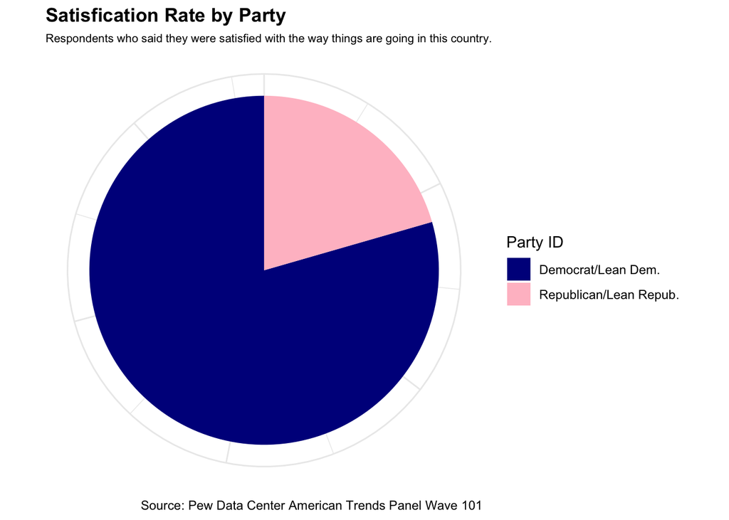

```r
chart2 <- chart2data %>%
  ggplot(aes (x = "", y = satisfied, fill=parties)) +
  geom_col() +
  coord_polar("y", start=0) +
  scale_fill_manual(values = c("darkblue", "pink")) +
  theme_minimal() +
  theme(
    axis.text = element_blank(),
    axis.ticks = element_blank(),
    axis.title = element_blank(),
    axis.line = element_blank(),
    plot.subtitle = element_text(size = 8),
    plot.title = element_text(face = "bold"),
  ) +
  labs(
    title = "Satisfication Rate by Party",
    subtitle = "Respondents who said they were satisfied with the way things are going in this country.",
    caption = "Source: Pew Data Center American Trends Panel Wave 101",
    fill = "Party ID")

chart2
```

The pie chart above gives the breakdown by party of respondents that say they are satisfied with the way things are going in the country. 79% of respondents who are satisfied with the country identify as Democrats compared to only 21% who identify as Republicans. Given that Democrats control both chambers of Congress and the Presidency during the time of this survey, this is not necessarily surprising. The proportions are likely not representative of the population as a whole given this is an unweighted proportion of respondents in our sample.